# Score d’escarre en réanimation

Philippe MICHEL

# Protocole

Pour établir un score de gravté il faut disposer de variables toutes factorielles, idéalement binaires, sinon ordonnées avec peu de valeurs possibles. Ces variables seront toutes celles parraissant significatives avec un seuil assez élevé (p <0,2 par ex.).

La mise au point du score se fera sur les sujets de l’étude PRESSURE (1162 cas utilisables), la validation sur ceux de l’étude AWARE.

```r
library("thesisph")
library("psy")
library("tidyverse")
library("missMDA")
library("epicalc")
library("factoextra")
library("lubridate")
library("knitr")
library("ROCR")
library("boot")
```

# Importation & mise en forme des variables

On ne garde que les patients n’ayant pas d’escarre à l’admission.

```r
tt <- read.csv("data/base2.csv", header = TRUE)
tt <- subset(tt,tt$adm.escarre == "0")
tt <- tt[,-27]
tt$nutrition <- as.factor(ifelse(tt$nutrition == 1,"per.os","artificielle"))
tt$classification.risque <- fct_relevel(tt$classification.risque,"Pas de risque","Risque faible", "Risque moyen" )
ddad <- dmy(tt$date_ad)
ddj <- dmy(tt$date_et)
dj <- 1 + ddj - ddad
dj <- as.numeric(dj)
ttc <- tt
#ttc$escarrej <- relevel(tt$escarrej,"non")
```

# Facteurs de risque connus

Pour mémoire les facteurs de risque d’escarre mis en évidence dans Pressure sont (en plus de l’IGS II) avec un seuil de significatibilité à 0,2:

- Sexe
- Poids
- Albumine
- CRP
- Ventilation
- Corticoïdes
- maladie neurologique
- Type de nutrition

Pour mémoire, en régression, les facteurs retrouvés sont :

- Poids > 90 Kg
- Corticoïdes
- Maladie neurologique

# Recherche de seuils

Pour les variables numériques (poids, albumine, CRP), on recherche un seuil * significatif * par les courbes de ROC.

Malheureusement ces trois variables ont des courbes ROC très plates sans seuil bien défini. Néanmoins des seuils un peu moins mauvais ont pu être trouvés :

- Poids : 90 Kg
- Albumine: 23
- CRP : 90

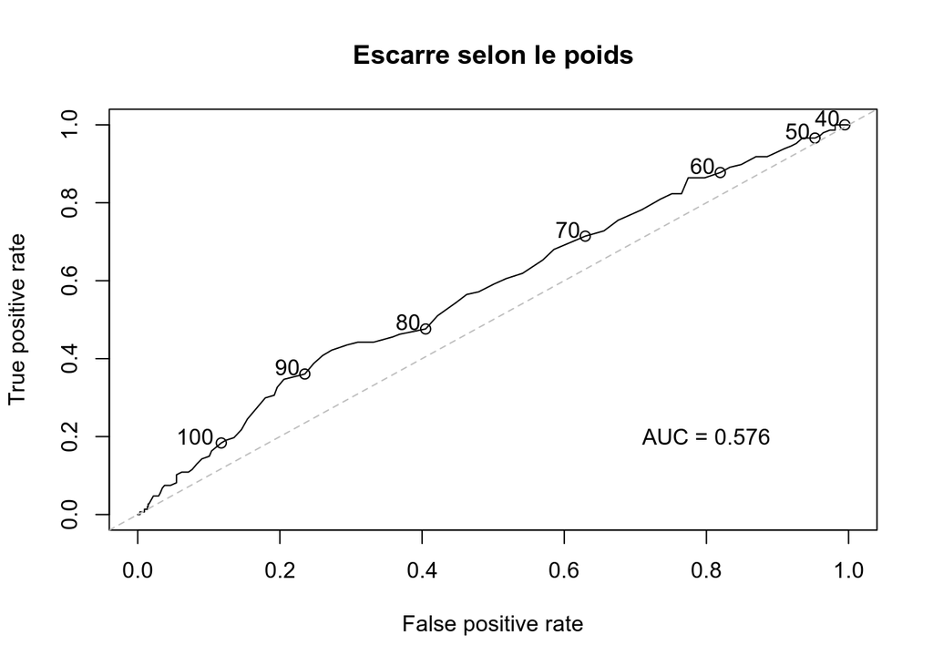

```r
rocph <- function(zz,titre,cutx){
  ff <- prediction(zz,tt$escarrej)
  zz <- performance(ff,"tpr","fpr")
  aucz <- performance(ff,"auc")
  aucx <- round(aucz@y.values[[1]],3 )
  plot(zz, colorize = FALSE, print.cutoffs.at = cutx, main = titre, text.adj=c(1.2,0.1))
  abline(a = 0, b = 1, col = "grey", lty = 2)
  text( x= 0.8, y = 0.2, paste0("AUC = ", aucx))
}
#
rocph(tt$poids_ad, "Escarre selon le poids", seq(40,100,10))
```

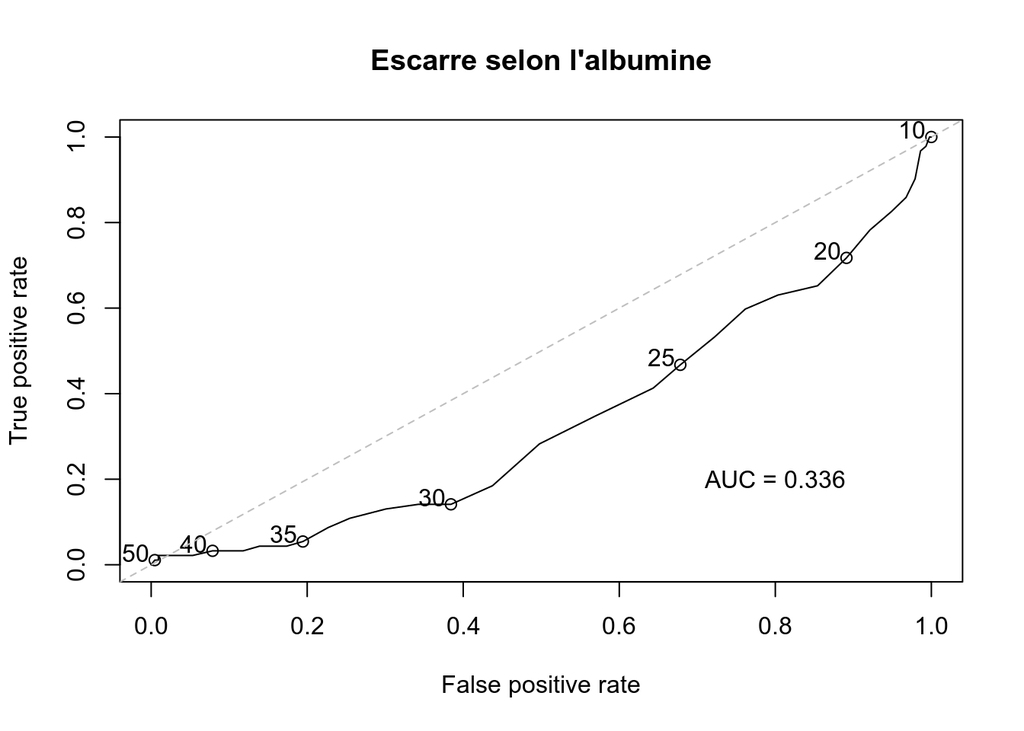

```r
rocph(tt$alb, "Escarre selon l'albumine", c(10,20,25,30,35,40,50))
```

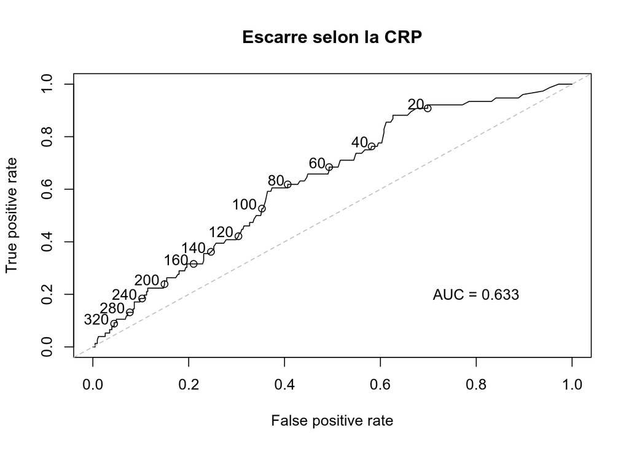

```r
rocph(tt$crp, "Escarre selon la CRP", c(seq(20,140,20),seq(160,320,40)))
```

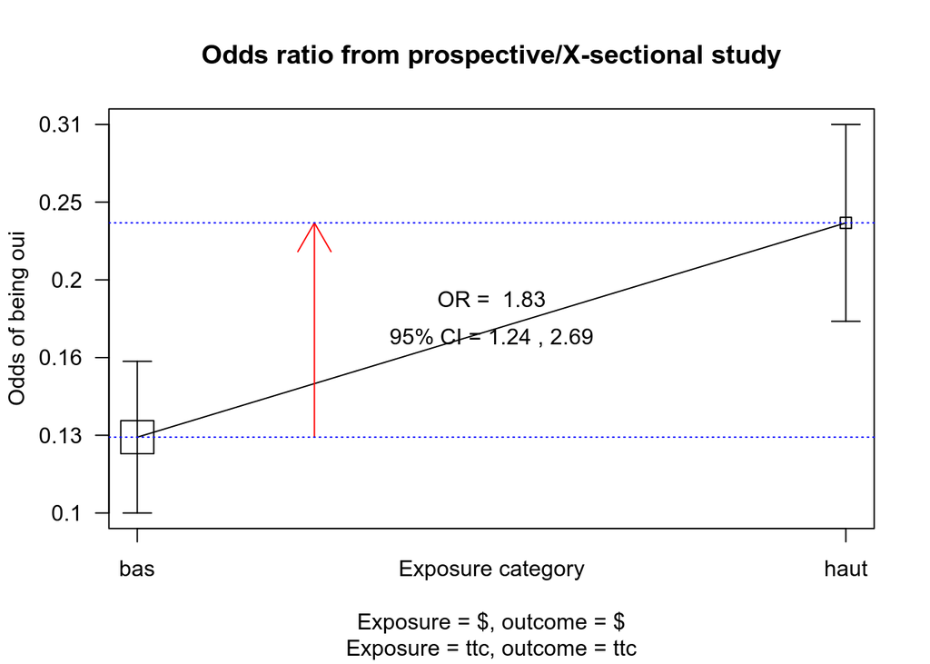

```
##
##             ttc$poids
## ttc$escarrej  bas haut Total
##        non    729  224   953
##        oui     94   53   147
##        Total  823  277  1100
##
## OR =  1.83
## Exact 95% CI =  1.24, 2.69
## Chi-squared = 10.65, 1 d.f., P value = 0.001
## Fisher's exact test (2-sided) P value = 0.002
```

```r
#
ttc$poids <- as.factor(ifelse(tt$poids_ad<90,"bas","haut"))
cc(ttc$escarrej,ttc$poids)
```

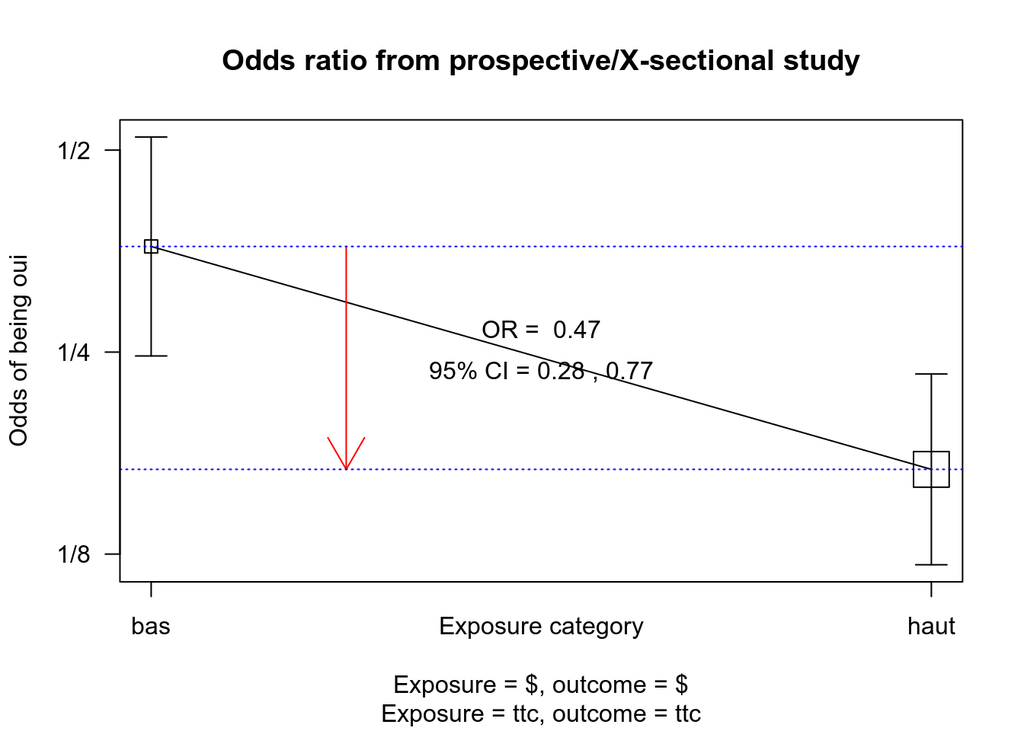

```
##
##             ttc$albumine
## ttc$escarrej bas haut Total
##        non   103  329   432
##        oui    37   55    92
##        Total 140  384   524
##
## OR =  0.47
## Exact 95% CI =  0.28, 0.77
## Chi-squared = 10.39, 1 d.f., P value = 0.001
## Fisher's exact test (2-sided) P value = 0.002
```

```r
#
ttc$albumine <- ifelse(tt$alb<23,"bas","haut")
cc(ttc$escarrej, ttc$albumine)
```

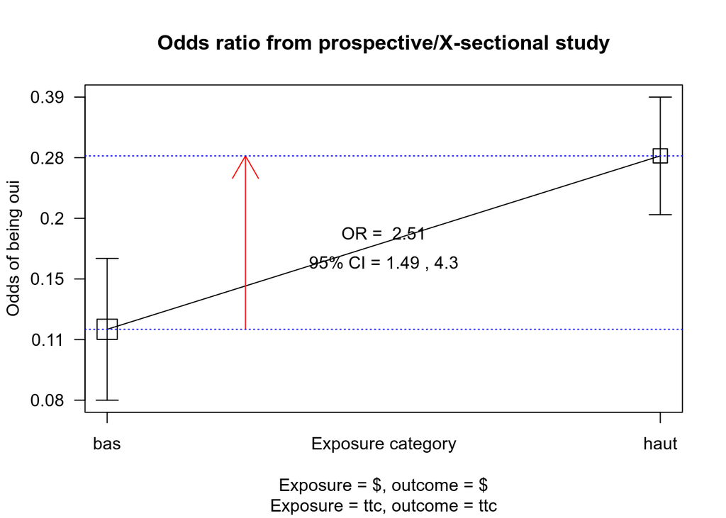

```
##
##             ttc$crp
## ttc$escarrej bas haut Total
##        non   266  162   428
##        oui    30   46    76
##        Total 296  208   504
##
## OR =  2.52
## Exact 95% CI =  1.49, 4.3
## Chi-squared = 13.69, 1 d.f., P value = 0
## Fisher's exact test (2-sided) P value = 0
```

```r
#
ttc$crp <- as.factor(ifelse(tt$crp<90,"bas","haut"))
cc(ttc$escarrej, ttc$crp)
```

```r
#
```

On dispose ainsi de variables factorielles simples, binaires pour tous les facteurs à étudier

# Régression logistique

```r
lgtt <- dim(tt)[1]
lgder <- floor(lgtt/3)
zz <- floor(runif(lgtt * 2, min = 1, max = lgtt))
zz <- unique(zz)
zz <- head(zz, lgder)
ttd <- tt[zz,] # groupe dérivation
ttv <- tt[-zz,] # groupe validation
```

## Sans pondération

### Calcul des variables à incorporer

```r
ll <- glm(escarrej ~
            alité.avant +
            sexe +
            poids +
            ventilation +
            corticoïdes +
            déficit.neuro +
            # albumine +
            # crp +
            nutrition,
          data = ttc,
          family = "binomial"
            )
logistic.display(ll, simplified = TRUE)
```

```
##
##                         OR lower95ci upper95ci     Pr(>|Z|)
## alité.avantoui   2.2816796 1.4390415 3.6177287 4.520821e-04
## sexeH            1.3241598 0.8360601 2.0972168 2.313955e-01
## poidshaut        1.9932576 1.2802729 3.1033037 2.259340e-03
## ventilationoui   1.1342641 0.6387165 2.0142817 6.672154e-01
## corticoïdesoui   2.6793408 1.7188511 4.1765496 1.352252e-05
## déficit.neurooui 2.7625928 1.7931911 4.2560543 4.056421e-06
## nutritionper.os  0.3239249 0.1852069 0.5665411 7.747841e-05
```

```r
sc1 = (ttc$alité.avant == "oui") +
     (ttc$poids == "haut") +
     (ttc$corticoïdes == "oui") +
     (ttc$déficit.neuro == "oui")
tt$sc1 <- sc1
tzz <- table(sc1,tt$escarrej)
tsc1 <- tzz[,2]
ssc1 <- rowSums(tzz)
cpc <- NULL
binf <- NULL
bsup <- NULL
for (ll in 1:5){
  bzz <- binom.test(tsc1[[ll]],ssc1[[ll]])
  cpc <- c(cpc,round(bzz$estimate[[1]]*100,1))
  binf <- c(binf,round(bzz$conf.int[[1]]*100,1))
  bsup <- c(bsup,round(bzz$conf.int[[2]]*100,1))
  #lig <- paste0(pcx," [",binf,";",bsup,"]")
}
zz <- data.frame(0:4,ssc1, cpc,binf,bsup)
names(zz) <- c("score","n","risque", "binf","bsup")
kable(zz, row.names = FALSE)
```

| score | n | risque | binf | bsup |
| --- | --- | --- | --- | --- |
| 0 | 390 | 4.6 | 2.8 | 7.2 |
| 1 | 373 | 12.9 | 9.6 | 16.7 |
| 2 | 181 | 26.0 | 19.7 | 33.0 |
| 3 | 43 | 48.8 | 33.3 | 64.5 |
| 4 | 2 | 100.0 | 15.8 | 100.0 |

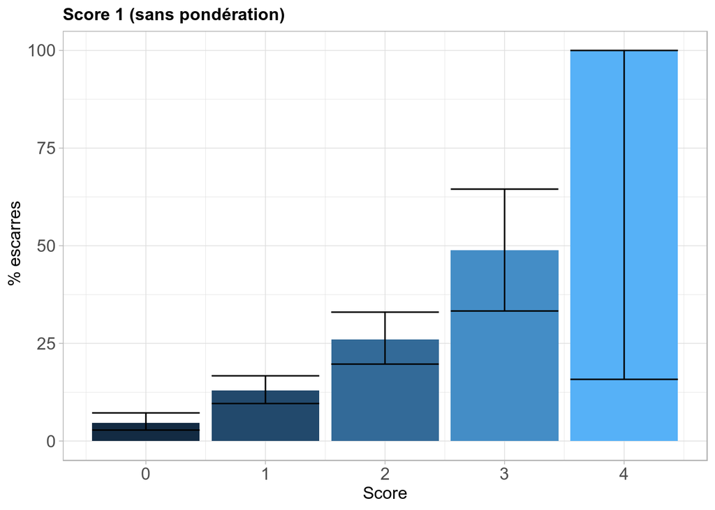

```r
ggplot(zz) +
  aes(x = score, y = risque, fill = score) +
  geom_bar(stat = "identity") +
  geom_errorbar(ymin = binf, ymax = bsup) +
  labs(title = "Score 1 (sans pondération)",
       x = "Score",
       y = " % escarres"
  ) +
  theme_light() +
  theme(plot.title = element_text(size = 12, face="bold"),
        axis.title.x = element_text(size = 12),
        axis.title.y = element_text(size = 12),
        axis.text.x = element_text(size = 12),
        axis.text.y = element_text(size = 12),
        legend.position = "none")
```

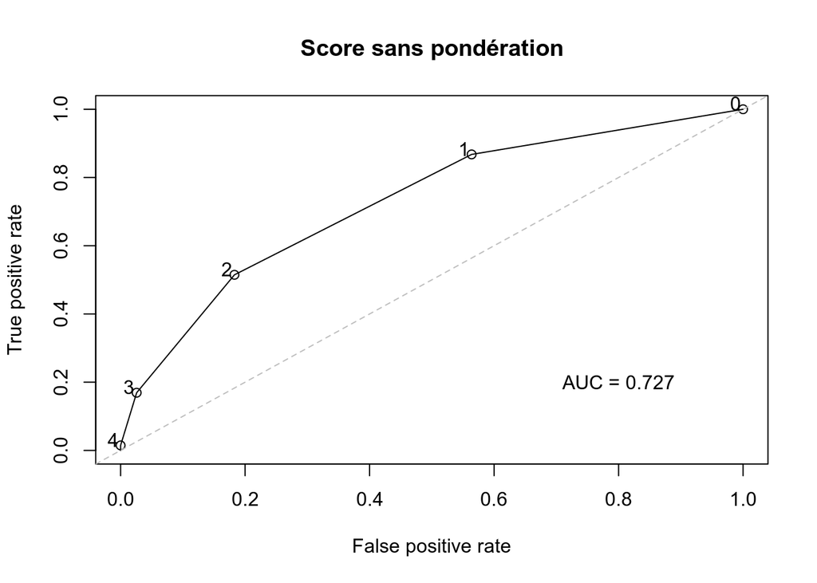

```r
rocph(sc1,"Score sans pondération", 0:4)
```

## Avec pondération

On applique une pondération basée sur les OD en gardant les mêmes items. On obtient donc alite avant x 2 + poids x 2 + corticïdes x 2 + deficit neuro x 3

Le plus grand nombre de niveaux rend la lecture moins nette, il faudra prévoir des regroupements de niveau.

```r
sc2 = (ttc$alité.avant == "oui") * 2 +
     (ttc$poids == "haut") * 2  +
     (ttc$corticoïdes == "oui") * 2 +
     (ttc$déficit.neuro == "oui") * 3
tt$sc2 <- sc2
tzz <- table(sc2,tt$escarrej)
tsc2 <- tzz[,2]
ssc2 <- rowSums(tzz)
cpc <- NULL
binf <- NULL
bsup <- NULL
for (ll in 1:8){
  bzz <- binom.test(tsc2[[ll]],ssc2[[ll]])
  cpc <- c(cpc,round(bzz$estimate[[1]]*100,1))
  binf <- c(binf,round(bzz$conf.int[[1]]*100,1))
  bsup <- c(bsup,round(bzz$conf.int[[2]]*100,1))
  #lig <- paste0(pcx," [",binf,";",bsup,"]")
}
zz <- data.frame(row.names(tzz),ssc2,cpc,binf,bsup)
names(zz) <- c("score","n","risque", "binf","bsup")
kable(zz, row.names = FALSE)
```

| score | n | risque | binf | bsup |
| --- | --- | --- | --- | --- |
| 0 | 390 | 4.6 | 2.8 | 7.2 |
| 2 | 277 | 10.1 | 6.8 | 14.3 |
| 3 | 96 | 20.8 | 13.2 | 30.3 |
| 4 | 89 | 23.6 | 15.2 | 33.8 |
| 5 | 92 | 28.3 | 19.4 | 38.6 |
| 6 | 8 | 50.0 | 15.7 | 84.3 |
| 7 | 35 | 48.6 | 31.4 | 66.0 |
| 9 | 2 | 100.0 | 15.8 | 100.0 |

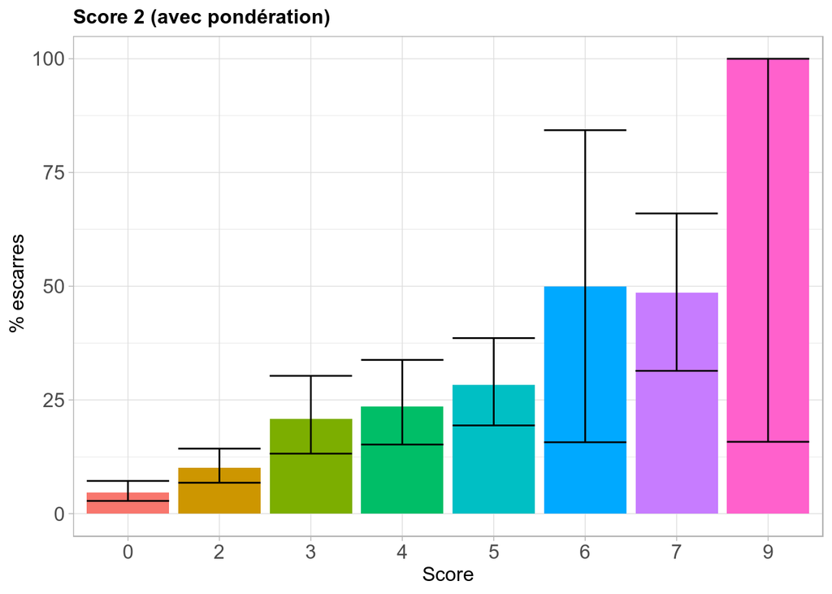

```r
ggplot(zz) +
  aes(x = score, y = risque, fill = score) +
  geom_bar(stat = "identity") +
  geom_errorbar(ymin = binf, ymax = bsup) +
  labs(title = "Score 2 (avec pondération)",
       x = "Score",
       y = " % escarres"
  ) +
  theme_light() +
  theme(plot.title = element_text(size = 12, face="bold"),
        axis.title.x = element_text(size = 12),
        axis.title.y = element_text(size = 12),
        axis.text.x = element_text(size = 12),
        axis.text.y = element_text(size = 12),
        legend.position = "none")
```

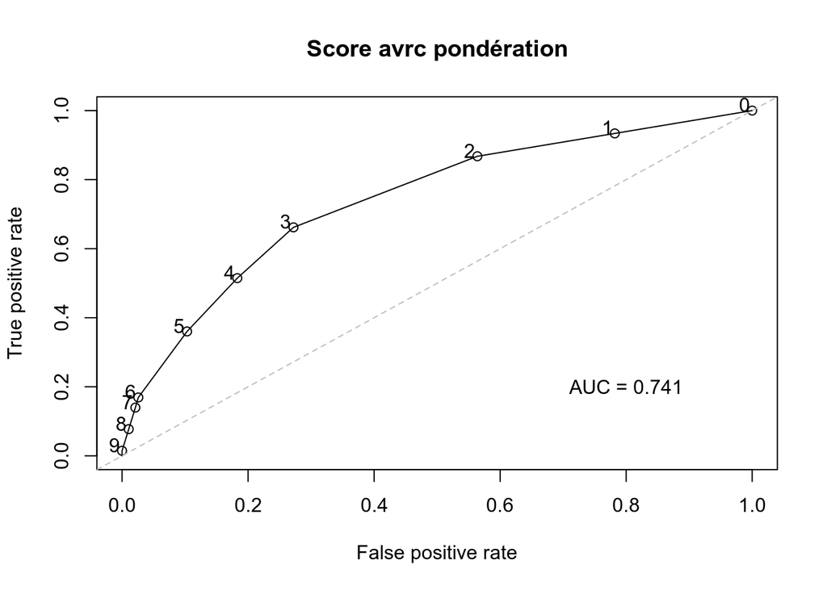

```r
rocph(sc2,"Score avrc pondération", 0:9)
```

## Scores “habituels”

Pour avoir un point de comparaison, voici la prédiction obtenue dans PRESSURE par l’échelle habituelle du service. Les résultats peuvent paraître corrects mais moins de 10 % des cas ont un risque faible & 1/3 un risque élevé soit une prédiction assez mauvaise avec des conséquences économiques importantes.

```r
schab = tt$classification.risque
tzz <- table(schab,tt$escarrej)
tschab <- tzz[,2]
sschab <- rowSums(tzz)
cpc <- NULL
binf <- NULL
bsup <- NULL
lg <- dim(tzz)[1]
for (ll in 1:lg){
  bzz <- binom.test(tschab[[ll]],sschab[[ll]])
  cpc <- c(cpc,round(bzz$estimate[[1]]*100,1))
  binf <- c(binf,round(bzz$conf.int[[1]]*100,1))
  bsup <- c(bsup,round(bzz$conf.int[[2]]*100,1))
  #lig <- paste0(pcx," [",binf,";",bsup,"]")
}
zz <- data.frame(row.names(tzz),sschab,cpc,binf,bsup)
names(zz) <- c("score","n","risque", "binf","bsup")
kable(zz, row.names = FALSE, format = "latex", booktabs = TRUE)
```

[output not shown]

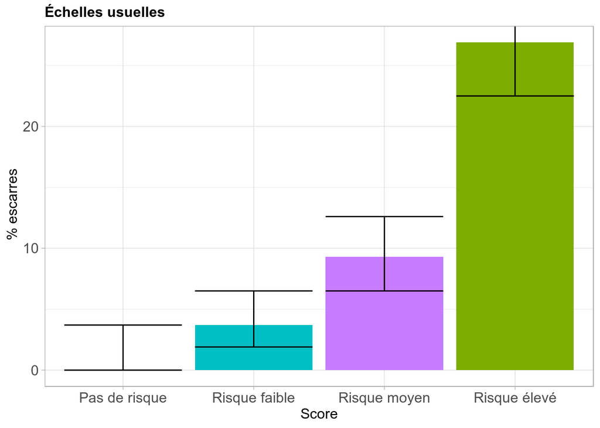

```r
ggplot(zz) +
  aes(x = fct_relevel(score,"Pas de risque","Risque faible", "Risque moyen"), y = risque, fill = score) +
  geom_bar(stat = "identity") +
  geom_errorbar(ymin = binf, ymax = bsup) +
  labs(title = "Échelles usuelles",
       x = "Score",
       y = " % escarres"
  ) +
  theme_light() +
  theme(plot.title = element_text(size = 12, face="bold"),
        axis.title.x = element_text(size = 12),
        axis.title.y = element_text(size = 12),
        axis.text.x = element_text(size = 12),
        axis.text.y = element_text(size = 12),
        legend.position = "none")
```

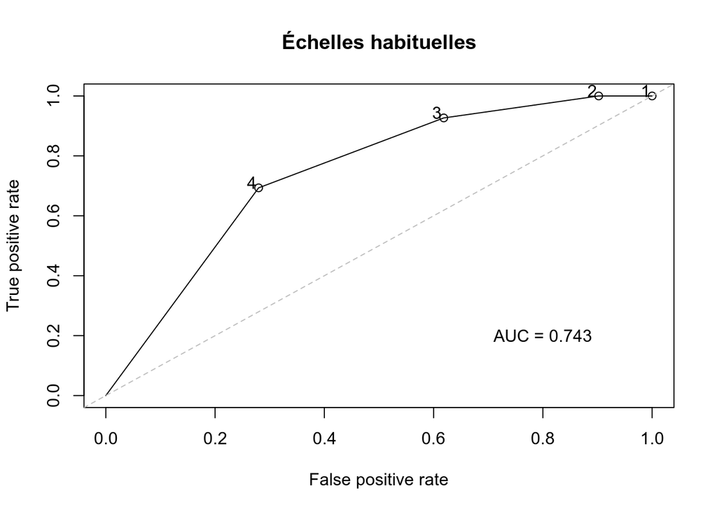

```r
rocph(as.numeric(tt$classification.risque),"Échelles habituelles",1:4)
```

## Validation des seuils

Pour chacun des deux scores étudiés on cherche le moins mauvais seuil.

## Score non modéré

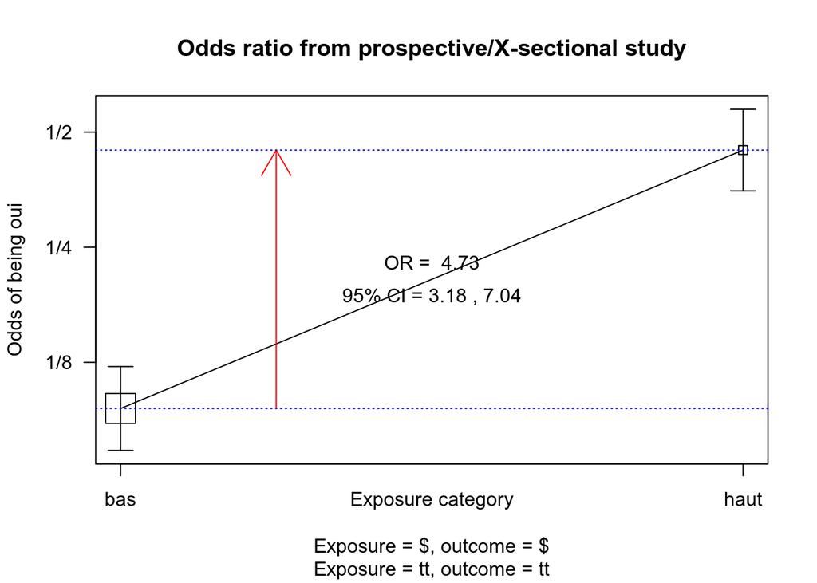

```
##
##            tt$seuil11
## tt$escarrej bas haut Total
##       non   697  156   853
##       oui    66   70   136
##       Total 763  226   989
##
## OR =  4.74
## Exact 95% CI =  3.18, 7.04
## Chi-squared = 73.26, 1 d.f., P value = 0
## Fisher's exact test (2-sided) P value = 0
```

```r
# Seuil <=2
tt$seuil11 <- as.factor(ifelse(tt$sc1 > 1,"haut","bas"))
cc(tt$escarrej,tt$seuil11)
```

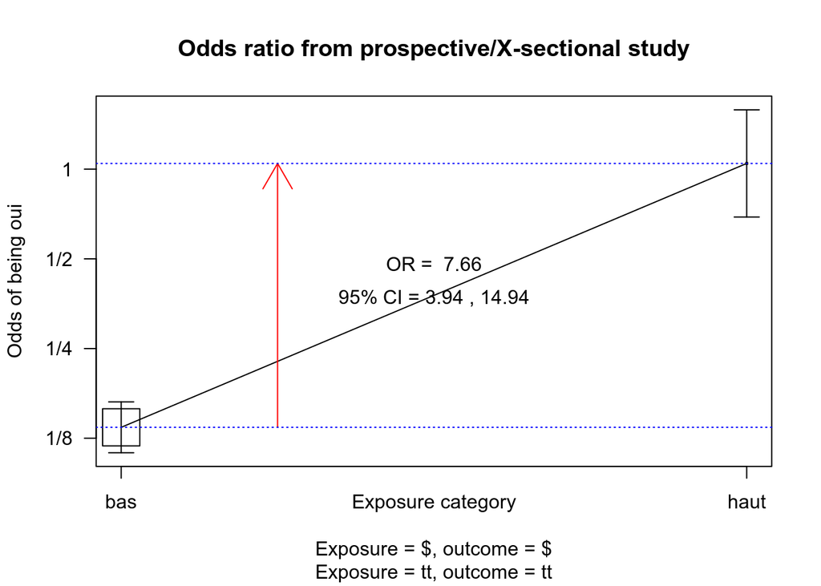

```
##
##            tt$seuil12
## tt$escarrej bas haut Total
##       non   831   22   853
##       oui   113   23   136
##       Total 944   45   989
##
## OR =  7.69
## Exact 95% CI =  3.94, 14.94
## Chi-squared = 55.48, 1 d.f., P value = 0
## Fisher's exact test (2-sided) P value = 0
```

```r
# Seuil <= 3
tt$seuil12 <- as.factor(ifelse(tt$sc1 > 2,"haut","bas"))
cc(tt$escarrej,tt$seuil12)
```

## Score pondéré

En essayant tous les seuils posiibles le meilleur OD est trouvé pour >=6 avec 12,0 % [10,0;14,2] d’escarre dans le groupe à bas risque vs 51,1 % [35,8;66,2] pour le groupe à haut risque.

```r
    tt$seuil2 <- as.factor(ifelse(tt$sc2 > 5,"haut","bas"))
    cc(tt$escarrej,tt$seuil2)
```

[figure not shown]

```
##
##            tt$seuil2
## tt$escarrej bas haut Total
##       non   831   22   853
##       oui   113   23   136
##       Total 944   45   989
##
## OR =  7.69
## Exact 95% CI =  3.94, 14.94
## Chi-squared = 55.48, 1 d.f., P value = 0
## Fisher's exact test (2-sided) P value = 0
```

# Conclusion

Les scores proposés isolent plus de patients avec un risque faible que les échelles habituelles. Donc un intérêt économique (moins de patients chez qui utiliser des méthodes de préventrions complexes & chères).